# Investigation of Health Insurance Premiums

IMPORTING VARIOUS PACKAGES

```python
import matplotlib.pyplot as plt
import seaborn as sns
import pandas as pd
import numpy as np
import scipy.stats
```

```python
df = pd.read_csv('insurance.csv') #Checking Imported Data#
print(df);
```

```
      age     sex     bmi  children smoker     region      charges
0      19  female  27.900         0    yes  southwest  16884.92400
1      18    male  33.770         1     no  southeast   1725.55230
2      28    male  33.000         3     no  southeast   4449.46200
3      33    male  22.705         0     no  northwest  21984.47061
4      32    male  28.880         0     no  northwest   3866.85520
...   ...     ...     ...       ...    ...        ...          ...
1333   50    male  30.970         3     no  northwest  10600.54830
1334   18  female  31.920         0     no  northeast   2205.98080
1335   18  female  36.850         0     no  southeast   1629.83350
1336   21  female  25.800         0     no  southwest   2007.94500
1337   61  female  29.070         0    yes  northwest  29141.36030

[1338 rows x 7 columns]
```

```python
df.isnull().sum()
```

```
age         0
sex         0
bmi         0
children    0
smoker      0
region      0
charges     0
dtype: int64
```

```python
df.charges = df.charges
```

```python
df['smokernumb'] = df.smoker.eq('yes').mul(1) #Adding Column for whether or not someone is a smoker#
print(df);
```

```
      age     sex     bmi  children smoker     region      charges  smokernumb
0      19  female  27.900         0    yes  southwest  16884.92400           1
1      18    male  33.770         1     no  southeast   1725.55230           0
2      28    male  33.000         3     no  southeast   4449.46200           0
3      33    male  22.705         0     no  northwest  21984.47061           0
4      32    male  28.880         0     no  northwest   3866.85520           0
...   ...     ...     ...       ...    ...        ...          ...         ...
1333   50    male  30.970         3     no  northwest  10600.54830           0
1334   18  female  31.920         0     no  northeast   2205.98080           0
1335   18  female  36.850         0     no  southeast   1629.83350           0
1336   21  female  25.800         0     no  southwest   2007.94500           0
1337   61  female  29.070         0    yes  northwest  29141.36030           1

[1338 rows x 8 columns]
```

```python
df['sexnumb'] = df.sex.eq('male').mul(1) #Adding Column for whether or not someone is a smoker#
print(df);
```

```
      age     sex     bmi  children smoker     region      charges  \
0      19  female  27.900         0    yes  southwest  16884.92400
1      18    male  33.770         1     no  southeast   1725.55230
2      28    male  33.000         3     no  southeast   4449.46200
3      33    male  22.705         0     no  northwest  21984.47061
4      32    male  28.880         0     no  northwest   3866.85520
...   ...     ...     ...       ...    ...        ...          ...
1333   50    male  30.970         3     no  northwest  10600.54830
1334   18  female  31.920         0     no  northeast   2205.98080
1335   18  female  36.850         0     no  southeast   1629.83350
1336   21  female  25.800         0     no  southwest   2007.94500
1337   61  female  29.070         0    yes  northwest  29141.36030

      smokernumb  sexnumb
0              1        0
1              0        1
2              0        1
3              0        1
4              0        1
...          ...      ...
1333           0        1
1334           0        0
1335           0        0
1336           0        0
1337           1        0

[1338 rows x 9 columns]
```

```python
df.describe() #Looking at General Statistics#
```

|  | age | bmi | children | charges | smokernumb | sexnumb |
| --- | --- | --- | --- | --- | --- | --- |
| count | 1338.000000 | 1338.000000 | 1338.000000 | 1338.000000 | 1338.000000 | 1338.000000 |
| mean | 39.207025 | 30.663397 | 1.094918 | 13270.422265 | 0.204783 | 0.505232 |
| std | 14.049960 | 6.098187 | 1.205493 | 12110.011237 | 0.403694 | 0.500160 |
| min | 18.000000 | 15.960000 | 0.000000 | 1121.873900 | 0.000000 | 0.000000 |
| 25% | 27.000000 | 26.296250 | 0.000000 | 4740.287150 | 0.000000 | 0.000000 |
| 50% | 39.000000 | 30.400000 | 1.000000 | 9382.033000 | 0.000000 | 1.000000 |
| 75% | 51.000000 | 34.693750 | 2.000000 | 16639.912515 | 0.000000 | 1.000000 |
| max | 64.000000 | 53.130000 | 5.000000 | 63770.428010 | 1.000000 | 1.000000 |

## BEGINNING OF DEMOGRAPHICS EXPLORATION

```python
print(min(df.age))
print(max(df.age));
```

```
18
64
```

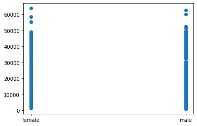

```python
plt.scatter(df.sex, df.charges) #Want to visualize initially and see what trends might appear w/ sex#
plt.show();
```

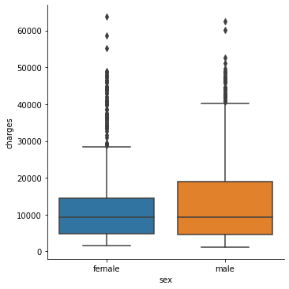

```python
sns.catplot(x='sex',y='charges',data=df,kind='box')
```

```python
print(df.groupby('sexnumb').describe())
```

```
           age                                                         bmi  \
         count       mean        std   min   25%   50%    75%   max  count
sexnumb
0        662.0  39.503021  14.054223  18.0  27.0  40.0  51.75  64.0  662.0
1        676.0  38.917160  14.050141  18.0  26.0  39.0  51.00  64.0  676.0

                    ...       charges              smokernumb            \
              mean  ...           75%          max      count      mean
sexnumb             ...
0        30.377749  ...  14454.691825  63770.42801      662.0  0.173716
1        30.943129  ...  18989.590250  62592.87309      676.0  0.235207


              std  min  25%  50%  75%  max
sexnumb
0        0.379152  0.0  0.0  0.0  0.0  1.0
1        0.424442  0.0  0.0  0.0  0.0  1.0

[2 rows x 40 columns]
```

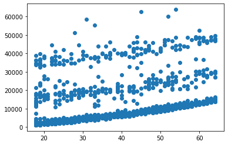

```python
plt.scatter(df.age, df.charges) #Want to visualize initially and see what trends might appear w/ age#
plt.show();
```

```python
df['bins_age'] = pd.cut(df['age'], [17,26, 34, 42, 50, 58, 68])
print(df.groupby(df.bins_age)['charges'].agg(['mean', 'std','count']))
```

```
                  mean           std  count
bins_age
(17, 26]   8839.442951  11496.123972    334
(26, 34]  10968.730405  11724.816564    215
(34, 42]  11973.124411  10899.822658    206
(42, 50]  15596.717745  11958.645409    227
(50, 58]  16329.881190  10975.090712    217
(58, 68]  20824.972901  12252.425356    139
```

There seems to be different tiers. However we can see that there tends to be a constant premium increase as age increases. From what we can see this trend especially continues with the baseline premiums.

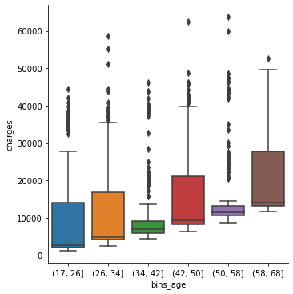

```python
sns.catplot(x='bins_age',y='charges',data=df,kind='box')
```

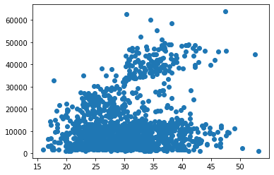

```python
plt.scatter(df.bmi,df.charges) #Want to visualize initially and see what trends might appear w/ bmi#
plt.show();
```

Can start to see a trend emerge on the front end - as bmi tends to increase do does premiums. Will need to further explore this data. Interestingly we hit around 30 and it seems to plateau. Not sure if this is due to any reason or trend.

```python
df['bins_bmi'] = pd.cut(df['bmi'], [15, 20, 25,30,35,40,45,50,60])
print(df.groupby(df.bins_bmi)['charges'].agg(['mean', 'std','count']))
```

```
                  mean           std  count
bins_bmi
(15, 20]   8838.561135   6896.326163     41
(20, 25]  10572.032183   7590.773060    206
(25, 30]  10997.803881   8067.254166    386
(30, 35]  14429.421062  13589.873520    389
(35, 40]  17022.258883  15171.514137    225
(40, 45]  16569.598306  16079.857446     71
(45, 50]  17815.036406  18768.080831     17
(50, 60]  16034.305367  24661.461378      3
```

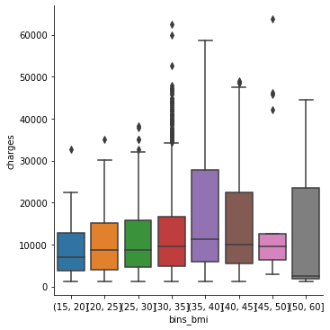

```python
sns.catplot(x='bins_bmi',y='charges',data=df,kind='box')
```

The three biggest takeaways are going to be the change in standard deviation along with the increase in the mean. We can see that the standard deviations are quite high so bmi is not a clear indicator of premium. This can be assumed because there are other big fators like smoking that can come into impact with this.

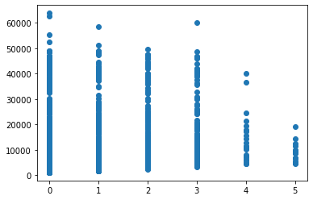

```python
plt.scatter(df.children,df.charges) #Want to visualize initially and see what trends might appear w/ children#
plt.show()
```

Another interesting trend seems to emerge. The more children you have the premium tends to decrease. However we do not see this with three children and this is the only that does not follow the trend.

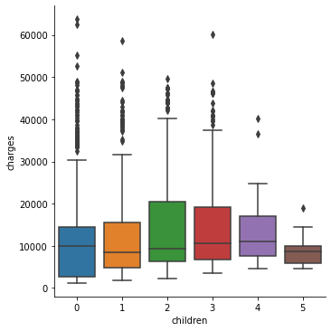

```python
sns.catplot(x='children',y='charges',data=df,kind='box')
```

```python
print(df.groupby('children').describe())
```

```
            age                                                         bmi  \
          count       mean        std   min    25%   50%   75%   max  count
children
0         574.0  38.444251  16.436228  18.0  22.00  36.0  55.0  64.0  574.0
1         324.0  39.453704  12.067445  18.0  30.00  40.0  49.0  64.0  324.0
2         240.0  39.445833  11.588715  18.0  30.00  40.0  48.0  64.0  240.0
3         157.0  41.566879  12.206174  18.0  31.00  41.0  52.0  64.0  157.0
4          25.0  39.000000  12.138094  18.0  29.00  39.0  48.0  61.0   25.0
5          18.0  35.611111  10.123583  19.0  28.75  39.0  42.5  52.0   18.0

                     ... smokernumb      sexnumb                           \
               mean  ...        75%  max   count      mean       std  min
children             ...
0         30.550296  ...        0.0  1.0   574.0  0.496516  0.500424  0.0
1         30.623148  ...        0.0  1.0   324.0  0.512346  0.500621  0.0
2         30.978104  ...        0.0  1.0   240.0  0.504167  0.501028  0.0
3         30.684331  ...        0.0  1.0   157.0  0.509554  0.501508  0.0
4         31.391200  ...        0.0  1.0    25.0  0.560000  0.506623  0.0
5         29.605000  ...        0.0  1.0    18.0  0.555556  0.511310  0.0


          25%  50%  75%  max
children
0         0.0  0.0  1.0  1.0
1         0.0  1.0  1.0  1.0
2         0.0  1.0  1.0  1.0
3         0.0  1.0  1.0  1.0
4         0.0  1.0  1.0  1.0
5         0.0  1.0  1.0  1.0

[6 rows x 40 columns]
```

Once people have 4-5 children we see the smoker rate drops significantly. Not sure on the cause of this, but could help mitigate the increase in premium costs.

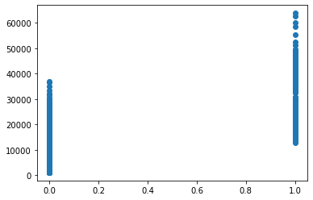

```python
plt.scatter(df.smokernumb,df.charges) #Want to visualize initially and see what trends might appear w/ smoking#
plt.show()
```

We can see if you are a smoker the premium is going to tend to be a lot higher. There is some overlap, but it is good to know that right off the bat we can expect higher premiums when smoking is involved.

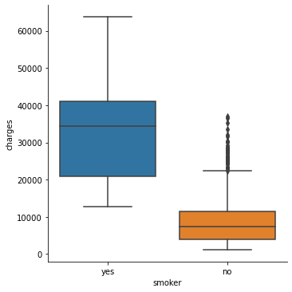

```python
sns.catplot(x='smoker',y='charges',data=df,kind='box')
```

```python
print(df.groupby('smokernumb').describe())
```

```
               age                                                       \
             count       mean        std   min    25%   50%   75%   max
smokernumb
0           1064.0  39.385338  14.083410  18.0  26.75  40.0  52.0  64.0
1            274.0  38.514599  13.923186  18.0  27.00  38.0  49.0  64.0

               bmi             ...       charges              sexnumb  \
             count       mean  ...           75%          max   count
smokernumb                     ...
0           1064.0  30.651795  ...  11362.887050  36910.60803  1064.0
1            274.0  30.708449  ...  41019.207275  63770.42801   274.0


                mean       std  min  25%  50%  75%  max
smokernumb
0           0.485902  0.500036  0.0  0.0  0.0  1.0  1.0
1           0.580292  0.494414  0.0  0.0  1.0  1.0  1.0

[2 rows x 40 columns]
```

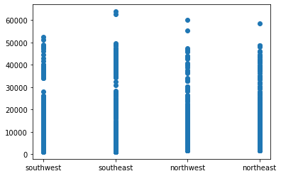

```python
plt.scatter(df.region,df.charges) #Want to visualize initially and see what trends might appear w/ regions#
plt.show()
```

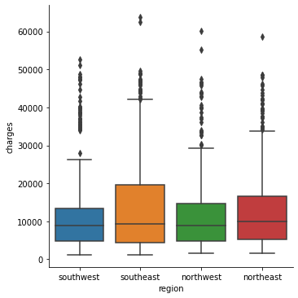

```python
sns.catplot(x='region',y='charges',data=df,kind='box')
```

```python
print(df.groupby('region').describe())
```

```
             age                                                         bmi  \
           count       mean        std   min    25%   50%   75%   max  count
region
northeast  324.0  39.268519  14.069007  18.0  27.00  39.5  51.0  64.0  324.0
northwest  325.0  39.196923  14.051646  19.0  26.00  39.0  51.0  64.0  325.0
southeast  364.0  38.939560  14.164585  18.0  26.75  39.0  51.0  64.0  364.0
southwest  325.0  39.455385  13.959886  19.0  27.00  39.0  51.0  64.0  325.0

                      ... smokernumb      sexnumb                           \
                mean  ...        75%  max   count      mean       std  min
region                ...
northeast  29.173503  ...       0.00  1.0   324.0  0.503086  0.500764  0.0
northwest  29.199785  ...       0.00  1.0   325.0  0.495385  0.500750  0.0
southeast  33.355989  ...       0.25  1.0   364.0  0.519231  0.500318  0.0
southwest  30.596615  ...       0.00  1.0   325.0  0.501538  0.500769  0.0


           25%  50%  75%  max
region
northeast  0.0  1.0  1.0  1.0
northwest  0.0  0.0  1.0  1.0
southeast  0.0  1.0  1.0  1.0
southwest  0.0  1.0  1.0  1.0

[4 rows x 48 columns]
```

```python
print(df.groupby(['region', 'smokernumb'])['charges'].agg(['mean', 'std','count']))
```

```
                              mean           std  count
region    smokernumb
northeast 0            9165.531672   6157.196439    257
          1           29673.536473  11589.559770     67
northwest 0            8556.463715   6128.553819    267
          1           30192.003182  11413.827702     58
southeast 0            8032.216309   6137.329758    273
          1           34844.996824  11324.766536     91
southwest 0            8019.284513   5489.514421    267
          1           32269.063494  11270.279593     58
```

```python
print(df.groupby(['sexnumb', 'smokernumb'])['charges'].agg(['mean', 'std','count']))
```

```
                            mean           std  count
sexnumb smokernumb
0       0            8762.297300   6060.775970    547
        1           30678.996276  11907.536381    115
1       0            8087.204731   5908.108989    517
        1           33042.005975  11202.670862    159
```

```python
print(df.groupby(['children', 'smokernumb'])['charges'].agg(['mean', 'std','count']))
```

```
                             mean           std  count
children smokernumb
0        0            7611.793335   5858.529189    459
         1           31341.363954  11596.678789    115
1        0            8303.109350   5987.135990    263
         1           31822.654334  11813.013604     61
2        0            9493.093674   6456.112895    185
         1           33844.235755  11311.748471     55
3        0            9614.519391   5159.770864    118
         1           32724.915268  11412.853656     39
4        0           12121.344408   7466.220703     22
         1           26532.276933  11952.285332      3
5        0            8183.845556   2911.244983     17
         1           19023.260000           NaN      1
```

```python
print(df.groupby(['bins_age', 'smokernumb'])['charges'].agg(['mean', 'std','count']))
```

```
                             mean           std  count
bins_age smokernumb
(17, 26] 0            4019.205149   5129.054326    266
         1           27695.079058   9986.073795     68
(26, 34] 0            5882.798097   4479.364566    167
         1           28663.536560  11974.517108     48
(34, 42] 0            7154.469515   3378.010590    163
         1           30239.188317  10206.211772     43
(42, 50] 0           10241.965409   4814.330259    176
         1           34075.863062  10772.219328     51
(50, 58] 0           12548.094919   4670.340243    184
         1           37416.204637  12147.162282     33
(58, 68] 0           15230.663972   5091.095708    108
         1           40314.823363   9640.165319     31
```

```python
print(df.groupby(['bins_bmi', 'smokernumb'])['charges'].agg(['mean', 'std','count']))
```

```
                             mean          std  count
bins_bmi smokernumb
(15, 20] 0            6129.459628  4180.135069     32
         1           18470.922050  6029.058743      9
(20, 25] 0            7830.728882  5936.881084    160
         1           20107.000185  4277.555007     46
(25, 30] 0            8226.088675  5910.704683    311
         1           22491.182935  5105.870553     75
(30, 35] 0            8549.952377  5932.738587    316
         1           39880.271809  5726.997837     73
(35, 40] 0            9670.440600  6645.189640    175
         1           42753.622873  5174.125749     50
(40, 45] 0            8435.977245  5651.414029     55
         1           44528.920703  3903.001034     16
(45, 50] 0            8076.633792  3071.699942     13
         1           49464.844903  9711.055907      4
(50, 60] 0            1800.758950   901.273000      2
         1           44501.398200          NaN      1
```

```python
print(df.groupby(['bins_bmi', 'bins_age'])['charges'].agg(['mean', 'std','count']))
```

```
                           mean           std  count
bins_bmi bins_age
(15, 20] (17, 26]   5392.004560   6232.495601     14
         (26, 34]  11286.261294   9979.307164      8
         (34, 42]   9603.960005   5432.216009     10
         (42, 50]   8444.038838    692.249076      4
         (50, 58]  13395.702825   6067.210307      4
         (58, 68]  13204.285650           NaN      1
(20, 25] (17, 26]   5853.298924   6783.877866     62
         (26, 34]   9997.271525   7365.079027     38
         (34, 42]  10510.738162   5785.989459     28
         (42, 50]  13375.031323   7427.512400     30
         (50, 58]  14717.848711   5988.217194     31
         (58, 68]  16660.756481   6256.375866     17
(25, 30] (17, 26]   7043.061248   7453.833475     94
         (26, 34]   8106.337551   6534.568529     63
         (34, 42]   9817.274459   7213.825853     70
         (42, 50]  13846.432940   7836.097886     75
         (50, 58]  14229.078158   6356.599086     48
         (58, 68]  18436.606689   7581.015263     36
(30, 35] (17, 26]  11121.162870  13619.147040     99
         (26, 34]  11424.506341  12617.694827     58
         (34, 42]  12363.146366  12562.367066     58
         (42, 50]  16386.562321  13971.163053     63
         (50, 58]  16626.618076  11822.626756     72
         (58, 68]  23151.176519  14485.891846     39
(35, 40] (17, 26]  10422.149042  14367.217234     44
         (26, 34]  17104.450010  18410.561764     36
         (34, 42]  17694.796562  15113.418861     25
         (42, 50]  18952.426677  15245.090104     39
         (50, 58]  16871.714435  12050.615426     42
         (58, 68]  22193.511017  13987.802645     39
(40, 45] (17, 26]  12451.355799  16545.947791     16
         (26, 34]   9062.997827  10956.540581     10
         (34, 42]  14214.694933  15258.590655     12
         (42, 50]  19449.801714  17089.364020     11
         (50, 58]  22399.481199  16477.546176     15
         (58, 68]  23724.776093  17170.155080      7
(45, 50] (17, 26]  22519.650150  27708.100065      2
         (26, 34]   4189.908350    702.129244      2
         (34, 42]  19635.135133  22930.980477      3
         (42, 50]  16299.895400  16537.587389      5
         (50, 58]  21806.323902  23480.692004      5
         (58, 68]           NaN           NaN      0
(50, 60] (17, 26]  16034.305367  24661.461378      3
         (26, 34]           NaN           NaN      0
         (34, 42]           NaN           NaN      0
         (42, 50]           NaN           NaN      0
         (50, 58]           NaN           NaN      0
         (58, 68]           NaN           NaN      0
```

```python
prediction_grouped = df.groupby(['smokernumb', 'bins_age','bins_bmi'])['charges'].agg(['mean','max','min','count'])
print(prediction_grouped)
```

```
                                      mean          max         min  count
smokernumb bins_age bins_bmi
0          (17, 26] (15, 20]   4016.913724  21595.38229   1241.5650     12
                    (20, 25]   4042.923772  25081.76784   1121.8739     53
                    (25, 30]   3998.472600  24671.66334   1252.4070     74
                    (30, 35]   4379.196514  26018.95052   1131.5066     77
                    (35, 40]   3581.175527  27724.28875   1141.4451     35
...                                    ...          ...         ...    ...
1          (58, 68] (30, 35]  47285.814854  52590.82939  45008.9555      9
                    (35, 40]  48006.043550  49577.66240  46599.1084      8
                    (40, 45]  48821.903200  48970.24760  48673.5588      2
                    (45, 50]           NaN          NaN         NaN      0
                    (50, 60]           NaN          NaN         NaN      0

[96 rows x 4 columns]
```

## Sorted Bins

```python
sorted_age_smoke = df.groupby(['bins_age','smokernumb'])['charges'].mean().sort_values(ascending=False).reset_index()
print(sorted_age_smoke)
```

```
    bins_age  smokernumb       charges
0   (58, 68]           1  40314.823363
1   (50, 58]           1  37416.204637
2   (42, 50]           1  34075.863062
3   (34, 42]           1  30239.188317
4   (26, 34]           1  28663.536560
5   (17, 26]           1  27695.079058
6   (58, 68]           0  15230.663972
7   (50, 58]           0  12548.094919
8   (42, 50]           0  10241.965409
9   (34, 42]           0   7154.469515
10  (26, 34]           0   5882.798097
11  (17, 26]           0   4019.205149
```

```python
sorted_bmi_smoke = df.groupby(['bins_bmi','smokernumb'])['charges'].mean().sort_values(ascending=False).reset_index()
print(sorted_bmi_smoke)
```

```
    bins_bmi  smokernumb       charges
0   (45, 50]           1  49464.844903
1   (40, 45]           1  44528.920703
2   (50, 60]           1  44501.398200
3   (35, 40]           1  42753.622873
4   (30, 35]           1  39880.271809
5   (25, 30]           1  22491.182935
6   (20, 25]           1  20107.000185
7   (15, 20]           1  18470.922050
8   (35, 40]           0   9670.440600
9   (30, 35]           0   8549.952377
10  (40, 45]           0   8435.977245
11  (25, 30]           0   8226.088675
12  (45, 50]           0   8076.633792
13  (20, 25]           0   7830.728882
14  (15, 20]           0   6129.459628
15  (50, 60]           0   1800.758950
```

## Beginning of Correlation Exploration

```python
print(scipy.stats.pearsonr(df.smokernumb,df.charges))

print(scipy.stats.pearsonr(df.bmi,df.charges))

print(scipy.stats.pearsonr(df.children,df.charges))

print(scipy.stats.pearsonr(df.age,df.charges))

print(scipy.stats.pearsonr(df.sexnumb,df.charges))
```

```
(0.7872514304984773, 8.27143584217778e-283)
(0.19834096883362887, 2.459085535117846e-13)
(0.0679982268479048, 0.012852128520141125)
(0.29900819333064765, 4.8866933317203816e-29)
(0.05729206220202535, 0.03613272100594507)
```

Based on our initial emploration we can see that smokers are by far the most correlated. We can also see that age and bmi follow with relatively low correlations. This is interesting as upon observing the data we can see clear trends that might not have a high correlation.

```python
corr_matrix = df.corr().abs()
print(corr_matrix);
```

```
                 age       bmi  children   charges  smokernumb   sexnumb
age         1.000000  0.109272  0.042469  0.299008    0.025019  0.020856
bmi         0.109272  1.000000  0.012759  0.198341    0.003750  0.046371
children    0.042469  0.012759  1.000000  0.067998    0.007673  0.017163
charges     0.299008  0.198341  0.067998  1.000000    0.787251  0.057292
smokernumb  0.025019  0.003750  0.007673  0.787251    1.000000  0.076185
sexnumb     0.020856  0.046371  0.017163  0.057292    0.076185  1.000000
```

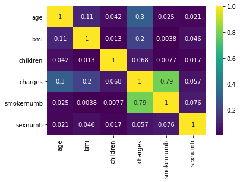

```python
sns.heatmap(corr_matrix, cmap='viridis', annot=True)
```

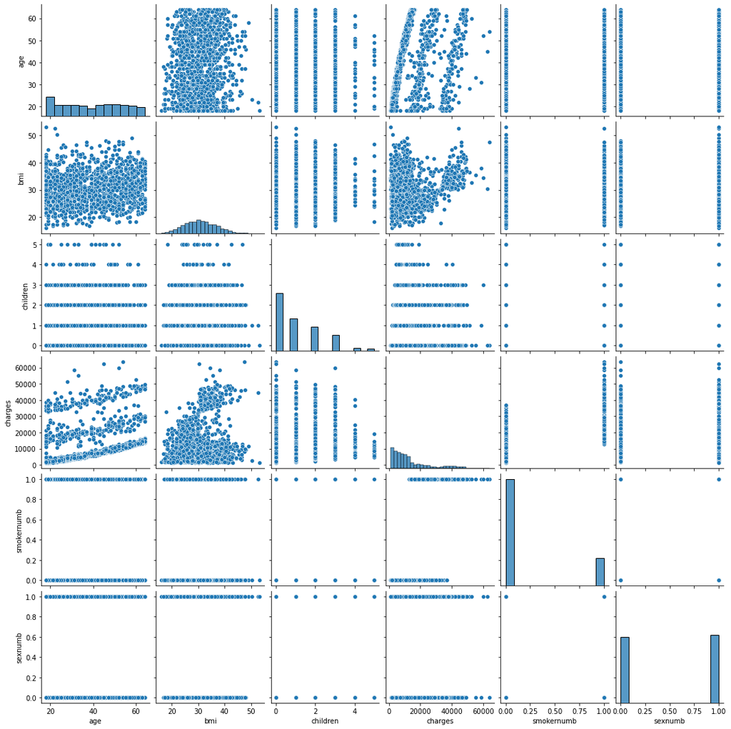

```python
sns.pairplot(df)
```

## Quartiles

```python
Q1 = df.quantile(q=0.25)
Q3 = df.quantile(q=0.75)
IQR = Q3 - Q1
print(IQR)
print(Q1)
print(Q3);
```

```
age              24.000000
bmi               8.397500
children          2.000000
charges       11899.625365
smokernumb        0.000000
sexnumb           1.000000
dtype: float64
age             27.00000
bmi             26.29625
children         0.00000
charges       4740.28715
smokernumb       0.00000
sexnumb          0.00000
Name: 0.25, dtype: float64
age              51.000000
bmi              34.693750
children          2.000000
charges       16639.912515
smokernumb        0.000000
sexnumb           1.000000
Name: 0.75, dtype: float64
```

## Building Detailed Graphs

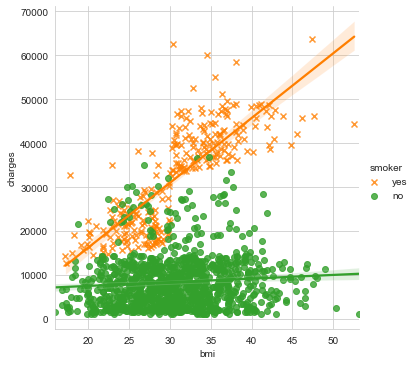

```python
sns.set_style("whitegrid")
sns.lmplot(x='bmi', y='charges', data=df,fit_reg=True,hue='smoker',palette='Paired_r', markers=['x','o'])
plt.show()
```

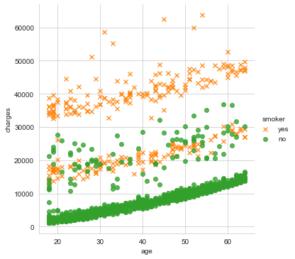

```python
sns.set_style("whitegrid")
sns.lmplot(x='age', y='charges', data=df,fit_reg=False,hue='smoker',palette='Paired_r',markers=['x','o'])
```

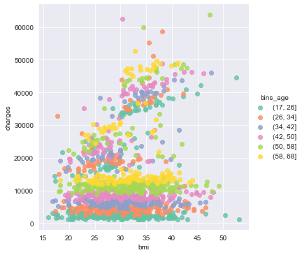

```python
sns.set_style("darkgrid")
sns.set_palette("RdBu")
sns.lmplot(x='bmi', y='charges', data=df,fit_reg=False,hue='bins_age',palette='Set2')
```

## Predicting Premiums - Based on Age and Smoking

```python
from sklearn import linear_model #importing regression model
```

```python
X = df[['smokernumb', 'age']]
y = df['charges']
```

```python
regr = linear_model.LinearRegression()
regr.fit(X, y)
```

```
LinearRegression()
```

```python
predicted_premium = regr.predict([[0,25]]) #User Inputed Data to Determine Premium
```

```python
print(predicted_premium)
```

```
[4480.15328752]
```

## Linear Regression Model

```python
from sklearn.linear_model import LinearRegression
from sklearn.model_selection import train_test_split
from sklearn.metrics import mean_absolute_error
import statsmodels.api as sm
from statsmodels.tools.eval_measures import mse, rmse
import seaborn as sns
pd.options.display.float_format = '{:.5f}'.format
import warnings
import math
import scipy.stats as stats
import scipy
from sklearn.preprocessing import scale
warnings.filterwarnings('ignore')
```

```python
y1=df['charges']
X1=df[['sexnumb','bmi', 'age','smokernumb','children']]
```

```python
X1_train, X1_test, y1_train, y1_test = train_test_split(X1, y1, test_size = 0.25, train_size = 0.75, random_state = 42)
```

```python
print('Training Data Count: {}'.format(X1_train.shape[0]))
print('Testing Data Count: {}'.format(X1_test.shape[0]))
```

```
Training Data Count: 1003
Testing Data Count: 335
```

```python
X1_train = sm.add_constant(X1_train)
results = sm.OLS(y1_train, X1_train).fit()
results.summary()
```

OLS Regression Results

| Dep. Variable: | charges | R-squared: | 0.744 |
| --- | --- | --- | --- |
| Model: | OLS | Adj. R-squared: | 0.743 |
| Method: | Least Squares | F-statistic: | 580.0 |
| Date: | Tue, 14 Dec 2021 | Prob (F-statistic): | 3.98e-292 |
| Time: | 13:29:26 | Log-Likelihood: | -10164. |
| No. Observations: | 1003 | AIC: | 2.034e+04 |
| Df Residuals: | 997 | BIC: | 2.037e+04 |
| Df Model: | 5 |  |  |
| Covariance Type: | nonrobust |  |  |

|  | coef | std err | t | P>\|t\| | [0.025 | 0.975] |
| --- | --- | --- | --- | --- | --- | --- |
| const | -1.23e+04 | 1121.474 | -10.968 | 0.000 | -1.45e+04 | -1.01e+04 |
| sexnumb | 66.0697 | 386.570 | 0.171 | 0.864 | -692.515 | 824.655 |
| bmi | 327.5600 | 32.307 | 10.139 | 0.000 | 264.162 | 390.958 |
| age | 260.0358 | 13.870 | 18.748 | 0.000 | 232.818 | 287.254 |
| smokernumb | 2.363e+04 | 478.849 | 49.344 | 0.000 | 2.27e+04 | 2.46e+04 |
| children | 434.8043 | 160.590 | 2.708 | 0.007 | 119.671 | 749.938 |

| Omnibus: | 241.068 | Durbin-Watson: | 2.068 |
| --- | --- | --- | --- |
| Prob(Omnibus): | 0.000 | Jarque-Bera (JB): | 592.918 |
| Skew: | 1.268 | Prob(JB): | 1.78e-129 |
| Kurtosis: | 5.785 | Cond. No. | 299. |

Notes:  
[1] Standard Errors assume that the covariance matrix of the errors is correctly specified.

Removing Sex as it is insignificant:

```python
X2=df[['age','bmi','children','smokernumb']]
y2 = df['charges']
X2_train, X2_test, y2_train, y2_test = train_test_split(X2, y2, test_size = 0.25, train_size = 0.75, random_state = 42)
```

```python
print('Training 2 Data Count:', X2_train.shape[0])
print('Testing 2 Data Count::', X2_test.shape[0])
```

```
Training 2 Data Count: 1003
Testing 2 Data Count:: 335
```

```python
X2_train = sm.add_constant(X2_train)
results2 = sm.OLS(y2_train, X2_train).fit()
results2.summary()
```

OLS Regression Results

| Dep. Variable: | charges | R-squared: | 0.744 |
| --- | --- | --- | --- |
| Model: | OLS | Adj. R-squared: | 0.743 |
| Method: | Least Squares | F-statistic: | 725.7 |
| Date: | Tue, 14 Dec 2021 | Prob (F-statistic): | 1.41e-293 |
| Time: | 13:29:26 | Log-Likelihood: | -10164. |
| No. Observations: | 1003 | AIC: | 2.034e+04 |
| Df Residuals: | 998 | BIC: | 2.036e+04 |
| Df Model: | 4 |  |  |
| Covariance Type: | nonrobust |  |  |

|  | coef | std err | t | P>\|t\| | [0.025 | 0.975] |
| --- | --- | --- | --- | --- | --- | --- |
| const | -1.227e+04 | 1104.744 | -11.105 | 0.000 | -1.44e+04 | -1.01e+04 |
| age | 260.0085 | 13.862 | 18.756 | 0.000 | 232.806 | 287.211 |
| bmi | 327.5784 | 32.291 | 10.144 | 0.000 | 264.212 | 390.945 |
| children | 435.2402 | 160.492 | 2.712 | 0.007 | 120.300 | 750.180 |
| smokernumb | 2.363e+04 | 477.923 | 49.449 | 0.000 | 2.27e+04 | 2.46e+04 |

| Omnibus: | 240.837 | Durbin-Watson: | 2.068 |
| --- | --- | --- | --- |
| Prob(Omnibus): | 0.000 | Jarque-Bera (JB): | 591.778 |
| Skew: | 1.267 | Prob(JB): | 3.14e-129 |
| Kurtosis: | 5.782 | Cond. No. | 294. |

Notes:  
[1] Standard Errors assume that the covariance matrix of the errors is correctly specified.

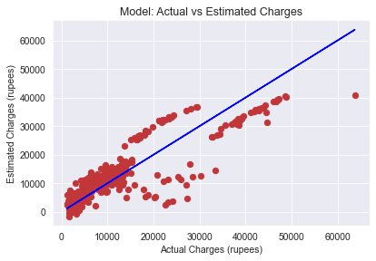

```python
X2_test = sm.add_constant(X2_test)

y2_preds = results2.predict(X2_test)

plt.figure(dpi = 75)
plt.scatter(y2_test, y2_preds)
plt.plot(y2_test, y2_test, color="blue")
plt.xlabel("Actual Charges (rupees)")
plt.ylabel("Estimated Charges (rupees)")
plt.title("Model: Actual vs Estimated Charges")
plt.show()
```

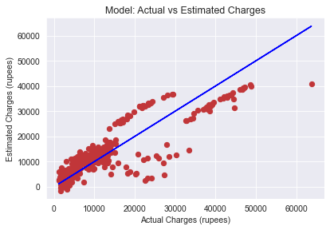

```python
X1_test = sm.add_constant(X1_test)

y1_preds = results.predict(X1_test)

plt.figure(dpi = 75)
plt.scatter(y1_test, y1_preds)
plt.plot(y1_test, y1_test, color="blue")
plt.xlabel("Actual Charges (rupees)")
plt.ylabel("Estimated Charges (rupees)")
plt.title("Model: Actual vs Estimated Charges")
plt.show()
```

```python
import ipywidgets as widgets
from IPython.display import display
```

```python
age_widget = widgets.IntSlider(
    value=38,
    min=18,
    max=64,
    step=1,
    description="Age:"
)

children_widget = widgets.IntSlider(
    value=1,
    min=0,
    max=5,
    step=1,
    description="Children:"
)

bmi_widget = widgets.FloatSlider(
    value=30,
    min=15,
    max=54,
    step=0.01,
    description="BMI:"
)

smoker_widget = widgets.ToggleButtons(
    options=['0', '1'],
    description="SmokerNumb:"
)

predict_btn = widgets.Button(
    description="Predict"
)

prediction_out = widgets.Output()

def make_prediction(btn):
    x1 = pd.DataFrame({
        'age':      age_widget.value,
        'bmi':      bmi_widget.value,
        'children': children_widget.value,
        'smoker':   smoker_widget.value
    }, index=[0])

    prediction2 = results2.predict(X2_test).reset_index(drop=True)
    #print(prediction2)
    with prediction_out:
        prediction_out.clear_output()
        print("Prediction: {:.2f}".format(prediction2[0]))

predict_btn.on_click(make_prediction)


display(age_widget, bmi_widget, smoker_widget, children_widget, predict_btn, prediction_out)
```